# projeto_01

## Autor

Carlos Augusto Jardim Chiarelli **165685**

$$ $$

```python
# bibliotecas
import  pandas            as pd
import  numpy             as np
import  matplotlib.pyplot as plt
from    numpy             import pi, sqrt
from    platform          import python_version
from    warnings          import filterwarnings
from    IPython.display   import Image
from    matplotlib.ticker import FormatStrFormatter
from    sklearn           import preprocessing

def cria_tabela():
    "{'Kf':np.nan, 'Kfs':np.nan, 'Se':np.nan, 'd':np.nan}"
    return pd.DataFrame({'Kf':[np.nan], 'Kfs':[np.nan], 'Se':[np.nan], 'd':[np.nan]})

def adiciona_linha(df, Kf, Kfs, Se, d):
    "Adiciona uma linha a tabela"
    ultima = df.shape[0]
    df.loc[ultima+1] = [Kf, Kfs, Se, d]
    return df

def interpola(x, par1, par2):
    '''
    :param x:       Float é a variável (X) conhecida do par
    :param par1:    Tuple (X1, Y1)
    :param par2:    Tuple (X2, Y2)
    :return:        Float é o número interpolado (variável Y desconhecida do par)
    '''
    X1, Y1 = par1
    X2, Y2 = par2
    Xa     = x

    Ya = (Xa - X1)/(X2 - X1)*(Y2 - Y1) + Y1

    return Ya

def plota_diametros(d1_df, d2_df, d3_df):

    df = d1_df.copy()
    df['d1'] = d1_df['d']
    df['d2'] = d2_df['d']
    df['d3'] = d3_df['d']
    df = df[['d1','d2','d3']]
    df *= 1e3
    df = df.reset_index(drop=True)

    plt.figure(figsize=(12,8))
    plt.rcParams.update({'font.size': 16}) # tamanho da fonte

    df.plot(marker='o', figsize=(12,8))
    plt.title('Convergência dos diâmetros\n')
    plt.xlabel('\niterações')
    plt.ylabel('diâmetro (mm)\n')
    plt.grid(color = 'b', alpha = 0.5, linestyle = 'dashed', linewidth = 0.5)
    plt.xticks([1,2,3,4,5],[1,2,3,4,5])
    plt.show()

def obtem_diametros_df(d1_df, d2_df, d3_df):
    d1, d2, d3 = d1_df.loc[6,'d'], d2_df.loc[6,'d'], d3_df.loc[6,'d']
    return pd.DataFrame({'diametro':[1,2,3], 'valor [m]':[d1,d2,d3]})

def plota_diagrama():
    plt.rcParams.update({'font.size': 16}) # tamanho da fonte

    titulos = ['Cisalhamento no plano Y-X', 'Cisalhamento no plano Z-X',
            'Momento no plano Y-X',      'Momento no plano Z-X',
            'Magnitude do Torque']

    eixo_y = [cis_yx, cis_zx, M_yx, M_zx, T_torsao]
    cor    = ['b', 'r']*2 + ['g']
    x = np.linspace(0, L[-1], len(L))

    #fig, axes = plt.subplots(nrows=3, ncols=2, figsize=(20, 10))
    fig, axes = plt.subplots(nrows=3, ncols=2, figsize=(18, 12))

    # gerando e plotando
    for titulo, y, cor, ax in zip(titulos, eixo_y, cor, axes.flat):

        ax.xaxis.set_major_formatter(FormatStrFormatter('%.2f'))

        ax.fill_between(x, y, color=cor, alpha=0.1)
        ax.plot(L, y, color=cor)

        ax.set_title(titulo)
        ax.hlines(0, 0, L[-1], colors='black', linewidth=3, linestyle = 'dashed')
        ax.grid(color = 'b', alpha = 0.5, linestyle = 'dashed', linewidth = 0.5)

    fig.tight_layout() # ajusta espaço entre gráficos
    plt.show()

def mostra_dados(dic, nome):
    ver = pd.DataFrame(dic)
    ver.index.name = nome
    return round(ver,1)

filterwarnings('ignore')               # remove warnings
plt.rcParams.update({'font.size': 16}) # tamanho da fonte (gráficos)

print('\nVersão da Linguagem Python usada neste relatório:', python_version())
```

```
Versão da Linguagem Python usada neste relatório: 3.7.6
```

$$ $$

# Projeto 01

$$ $$

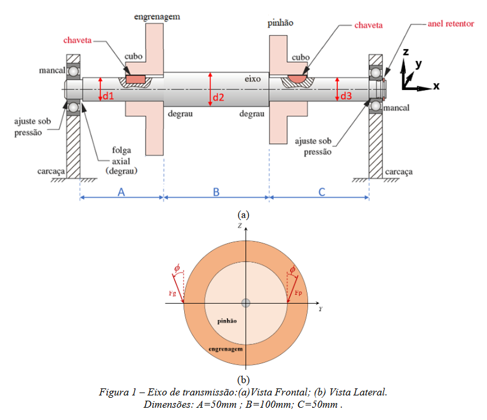

```python
Image('../dados/imagens/proj01_fig_projeto01.PNG')
```

## Dados:

$$ $$

- potência 3HP variando entre 1500 a 2000 RPM (cíclico) $$ $$
- Temperatura < 400°C $$ $$
- D_eng = 150 mm (engrenagem) $$ $$
- D_pinhao = 80 mm (pinhão) $$ $$
- $\phi = 20°$ $$ $$
- $r = 0.25$ mm (raio de entalhe nos rasgos no eixo) $$ $$
- dimensionamento para **vida infinita** $$ $$
- $C_{conf} = 90 % $ $ $ % (confiabilidade) $$ $$
- material eixo - processo de usinagem - aço SAE 1045 $$ $$
  - $S_{ut} = 627$ $MPa$ $$ $$
  - $S_{y} = 531$ $MPa$ $$ $$
- material chavetas - aço baixo-carbono SAE 1010 $$ $$
  - $S_{ut} = 365$ $MPa$ $$ $$
  - $S_{y} = 303$ $MPa$ $$ $$

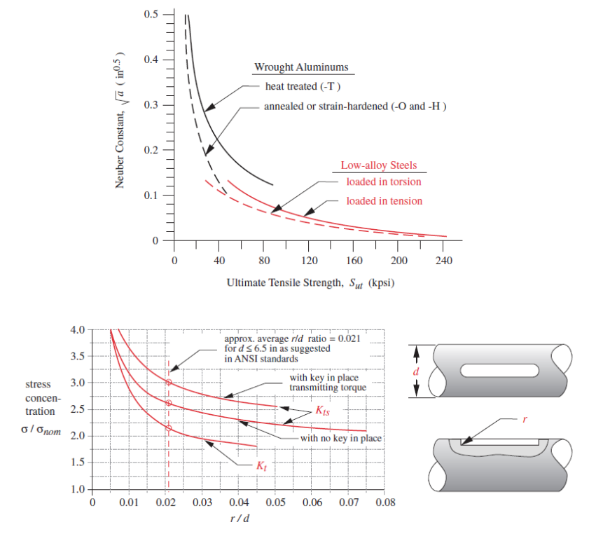

```python
Image('../dados/imagens/proj01_tabela_a2.PNG')
```

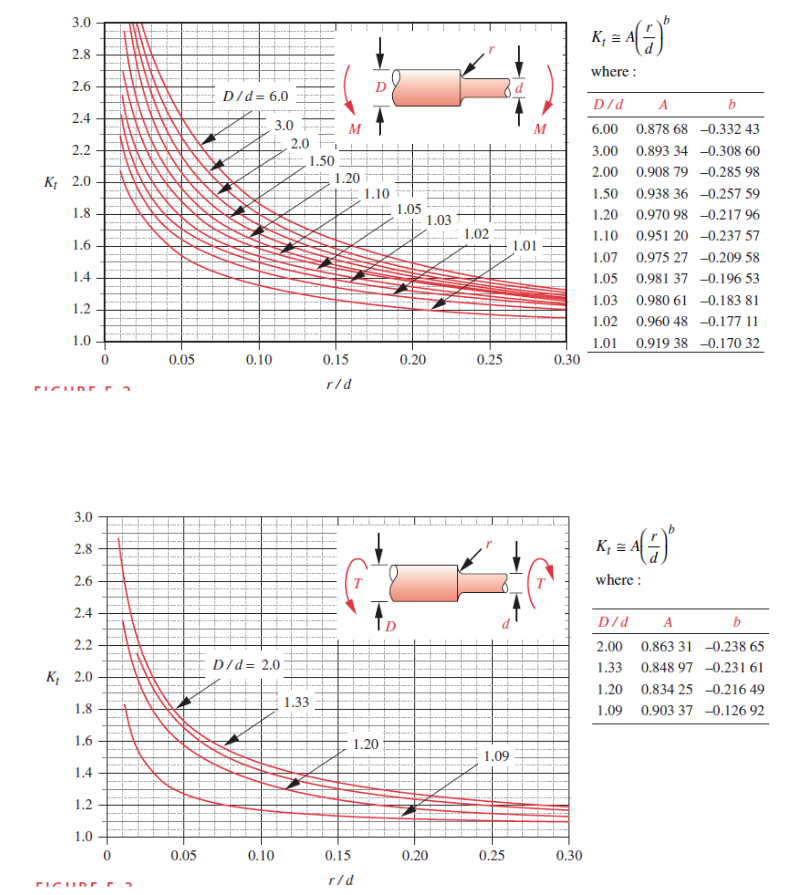

```python
Image('../dados/imagens/proj01_tabela_Kt.PNG')
```

$$ $$

## Solicitado:

Determinar os diâmetros das três principais secções deste eixode transmissão (**d1, d2 e d3**) considerando um coeficiente de segurança igual a 3.

Após isso, dimensionar as chavetas para a montagem da engrenagem e do pinhão. A escolha do tipo da chaveta é livre, ou seja, pode ser do tipo quadrada, retangular ou meia pastilha. $$ $$

```python
# propriedades do sistema

omega_min = 1500          # velocidade angular [RPM]
omega_max = 2000          # velocidade angular [RPM]
P         = 3             # potência [HP]
De, Dp    = 150e-3, 80e-3 # diâmetros engrenagem e pinhão [m]
Re, Rp    = De/2, Dp/2    # raios     engrenagem e pinhão [m]
phi       = 20            # graus
r         = 0.25e-3       # raio entalhe [m]
C_conf    = 0.9           # percentual
Sut_eixo  = 627e6         # Pa
Sy_eixo   = 531e6         # Pa
Sut_chav  = 365e6         # Pa
Sy_chav   = 303e6         # Pa
Nf        = 3             # coeficiente segurança

A, B, C   = 50e-3, 100e-3, 50e-3 # [m]
```

```python
omega_min = omega_min * (2*np.pi) / 60 # velocidade angular [rad/s]
omega_max = omega_max * (2*np.pi) / 60 # velocidade angular [rad/s]
omega_med = (omega_min + omega_max)/2

phi = phi * (np.pi / 180) # radianos

P = P * 745.7 # potência [W]
```

$$ $$

Abaixo vamos calcular o Torque inserido no sistema:

$$ T = \frac{P}{\omega} $$$$ $$

```python
T_min  = P/omega_max      # N.m
T_pico = P/omega_min      # N.m

T = {'medio':(T_pico+T_min)/2,
     'alt'  :(T_pico-T_min)/2}

print('T_medio = %.1f Nm\nT_alt = %.1f Nm' % (T['medio'],T['alt']))
```

```
T_medio = 12.5 Nm
T_alt = 1.8 Nm
```

$$ $$

Calculandos as **componentes tangencias** e **radiais** das **forças** na **engrenagem** e **pinhão**: $$ $$

```python
def forca_eng_pinhao(T):
    '''
    :param T: Float é o Torque
    :return:  2 Dictionarys (Fg, Fp) é o par das forças na engrenagem e pinhão (Fy, Fz)
    '''

    # forças engrenagem
    Fg_z  =  T/Re               # tangencial
    Fg_y  =  Fg_z * np.tan(phi) # radial
    Fg_z *= -1                  # correção sinal

    # forças pinhão
    Fp_z  = (T/Rp)             # tangencial
    Fp_y  = Fp_z * np.tan(phi) # radial
    Fp_z *= -1                 # correção sinal
    Fp_y *= -1                 # correção sinal

    return {'y':Fg_y,'z':Fg_z}, {'y':Fp_y,'z':Fp_z}
```

```python
Fg, Fp = {}, {} # Newton

Fg['medio'], Fp['medio'] = forca_eng_pinhao(T['medio'])
Fg['alt'],   Fp['alt']   = forca_eng_pinhao(T['alt'])
```

```python
mostra_dados(Fg, 'Fg [N]')
```

| Fg [N] | medio | alt |
| --- | --- | --- |
| y | 60.5 | 8.6 |
| z | -166.2 | -23.7 |

```python
mostra_dados(Fp, 'Fp [N]')
```

| Fp [N] | medio | alt |
| --- | --- | --- |
| y | -113.4 | -16.2 |
| z | -311.5 | -44.5 |

$$ $$

$$ $$

Cálculo das forças de reação:

$ $

$$ \sum M_{A} = 0 $$

$ $

$$ \sum F_{Z} = 0 $$

$ $

$$ \sum F_{Y} = 0 $$

$ $

Vamos considerar o ponto **A** no **mancal 1** (à esquerda) e ponto **D** no **mancal 2** (à direita). $$ $$

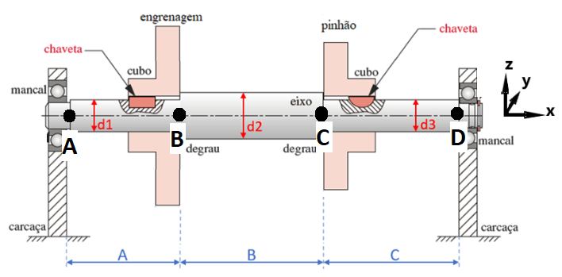

```python
Image('../dados/imagens/proj01_fig_projeto02.PNG')
```

```python
def reacoes_mancais(Fg, Fp):
    '''
    :param Fg: Dictionary é a força na engrenagem {'y':,'z':}
    :param Fp: Dictionary é a força no pinhão     {'y':,'z':}
    :return:  2 Dictionarys (Ra, Rd) é o par das forças na engrenagem e pinhão (Fy, Fz)
    '''

    Fg_y, Fg_z = Fg['y'], Fg['z']
    Fp_y, Fp_z = Fp['y'], Fp['z']

    # SOMA Ma
    Rd_y = -1/(A+B+C)*(Fg_y*A + Fp_y*(A+B))
    Rd_z = -1/(A+B+C)*(Fg_z*A + Fp_z*(A+B))

    # SOMA Fz e Fy
    Ra_y = -(Rd_y + Fg_y + Fp_y)
    Ra_z = -(Rd_z + Fg_z + Fp_z)

    return {'y':Ra_y,'z':Ra_z}, {'y':Rd_y,'z':Rd_z}
```

```python
Ra, Rd = {}, {} # Newton

Ra['medio'], Rd['medio'] = reacoes_mancais(Fg['medio'], Fp['medio'])
Ra['alt'],   Rd['alt']   = reacoes_mancais(Fg['alt'],   Fp['alt'])
```

```python
mostra_dados(Ra, 'Ra [N]')
```

| Ra [N] | medio | alt |
| --- | --- | --- |
| y | -17.0 | -2.4 |
| z | 202.5 | 28.9 |

```python
mostra_dados(Rd, 'Rd [N]')
```

| Rd [N] | medio | alt |
| --- | --- | --- |
| y | 69.9 | 10.0 |
| z | 275.2 | 39.3 |

$$ $$

$$ $$

Obtemos as seguintes funções de singularidade:

$ $

$$ q = R_{a} \langle x-0 \rangle ^{-1} + F_{g} \langle x-0.05 \rangle ^{-1} + F_{p} \langle x-0.15 \rangle ^{-1} + R_{d} \langle x-0.2 \rangle ^{-1} $$

$ $

$$ V = R_{a} \langle x-0 \rangle ^0 + F_{g} \langle x-0.05 \rangle ^0 + F_{p} \langle x-0.15 \rangle ^0 + R_{d} \langle x-0.2 \rangle ^0 $$

$ $

$$ M = R_{a} \langle x-0 \rangle ^1 + F_{g} \langle x-0.05 \rangle ^1 + F_{p} \langle x-0.15 \rangle ^1 + R_{d} \langle x-0.2 \rangle ^1 $$

$ $

```python
L = np.arange(0, A+B+C*1.1, 10e-4) # comprimento em X

Fg_y, Fp_y, Ra_y, Rd_y = Fg['medio']['y'], Fp['medio']['y'], Ra['medio']['y'], Rd['medio']['y']
Fg_z, Fp_z, Ra_z, Rd_z = Fg['medio']['z'], Fp['medio']['z'], Ra['medio']['z'], Rd['medio']['z']

def V_y(x):
    if x < A:
        return Ra_y
    elif x >= A and x < (A+B):
        return Ra_y + Fg_y
    elif x >= (A+B) and x < (A+B+C):
        return Ra_y + Fg_y + Fp_y
    else:
        return Ra_y + Fg_y + Fp_y + Rd_y

def V_z(x):
    if x < A:
        return Ra_z
    elif x >= A and x < (A+B):
        return Ra_z + Fg_z
    elif x >= (A+B) and x < (A+B+C):
        return Ra_z + Fg_z + Fp_z
    else:
        return Ra_z + Fg_z + Fp_z + Rd_z

def M_z(x):
    if x < A:
        return Ra_z*x
    elif x >= A and x < (A+B):
        return Ra_z*x + Fg_z*(x-A)
    elif x >= (A+B) and x < (A+B+C):
        return Ra_z*x + Fg_z*(x-A) + Fp_z*(x-A-B)
    else:
        return Ra_z*x + Fg_z*(x-A) + Fp_z*(x-A-B) + Rd_z*(x-A-B-C)

def M_y(x):
    if x < A:
        return Ra_y*x
    elif x >= A and x < (A+B):
        return Ra_y*x + Fg_y*(x-A)
    elif x >= (A+B) and x < (A+B+C):
        return Ra_y*x + Fg_y*(x-A) + Fp_y*(x-A-B)
    else:
        return Ra_y*x + Fg_y*(x-A) + Fp_y*(x-A-B) + Rd_y*(x-A-B-C)

# esforço cortante (cisalhamento)
cis_yx = list(map(V_y, L))
cis_zx = list(map(V_z, L))

# momento fletor (flexão)
M_yx = list(map(M_y, L))
M_zx = list(map(M_z, L))

# torção (momento torsor)
T_torsao = np.zeros(len(L))
T_torsao[(L >= A) &(L < A+B)] = -T['medio']
```

$$ $$

## Diagramas das componentes médias

$$ $$

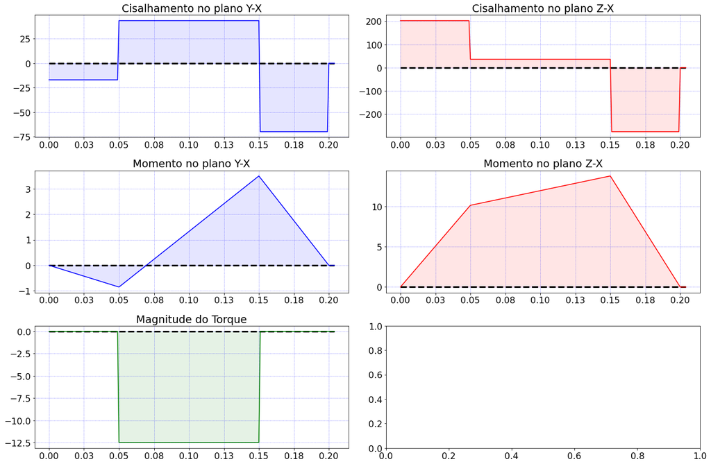

```python
plota_diagrama()
```

```python
Fg_y, Fp_y, Ra_y, Rd_y = Fg['alt']['y'], Fp['alt']['y'], Ra['alt']['y'], Rd['alt']['y']
Fg_z, Fp_z, Ra_z, Rd_z = Fg['alt']['z'], Fp['alt']['z'], Ra['alt']['z'], Rd['alt']['z']

# esforço cortante (cisalhamento)
cis_yx = list(map(V_y, L))
cis_zx = list(map(V_z, L))

# momento fletor (flexão)
M_yx = list(map(M_y, L))
M_zx = list(map(M_z, L))

# torção (momento torsor)
T_torsao = np.zeros(len(L))
T_torsao[(L >= A) &(L < A+B)] = -T['alt']
```

$$ $$

## Diagramas das componentes alternadas

$$ $$

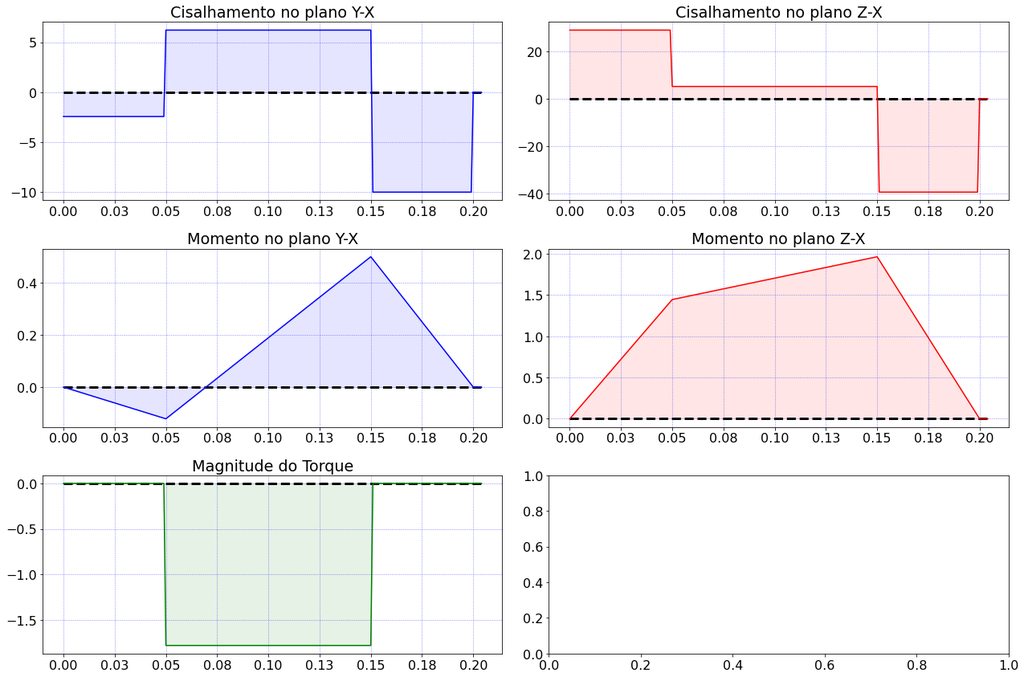

```python
plota_diagrama()
```

$$ $$

$$ $$

Calculando a magnitude dos momentos nos pontos $B$ e $C$: $$ $$

```python
Mb, Mc = {}, {}

Fg_y, Fp_y, Ra_y, Rd_y = Fg['medio']['y'], Fp['medio']['y'], Ra['medio']['y'], Rd['medio']['y']
Fg_z, Fp_z, Ra_z, Rd_z = Fg['medio']['z'], Fp['medio']['z'], Ra['medio']['z'], Rd['medio']['z']

# Momentos Médio
Mb['medio'] = sqrt((M_y(A)**2 + M_z(A)**2))
Mc['medio'] = sqrt((M_y(A+B)**2 + M_z(A+B)**2))

# Momentos alternados
Fg_y, Fp_y, Ra_y, Rd_y = Fg['alt']['y'], Fp['alt']['y'], Ra['alt']['y'], Rd['alt']['y']
Fg_z, Fp_z, Ra_z, Rd_z = Fg['alt']['z'], Fp['alt']['z'], Ra['alt']['z'], Rd['alt']['z']

Mb['alt'] = sqrt((M_y(A)**2 + M_z(A)**2))
Mc['alt'] = sqrt((M_y(A+B)**2 + M_z(A+B)**2))
```

```python
mostra_dados({'Mb':Mb,'Mc':Mc}, 'M [Nm]')
```

| M [Nm] | Mb | Mc |
| --- | --- | --- |
| medio | 10.2 | 14.2 |
| alt | 1.5 | 2.0 |

$$ $$

$$ $$

Agora é necessário encontrar o limite de resistência à fadiga corrigido ($S_{e}$):

$$ $$$$ S_{e} = C_{carreg}C_{tam}C_{sup}C_{temp}C_{conf}S′_{e} $$$$ $$

```python
Se_linha = 0.5*Sut_eixo # aço vida infinita
C_carreg = 1            # carregamento é flexão alternada
C_tam    = 1            # chute inicial

# material usinado (superfície)
A_sup, b_sup  = 4.51, -0.265
C_sup         = A_sup*((Sut_eixo*1e-6)**b_sup)

C_temp = 1     # T < 450°C
C_conf = 0.897 # 90%

Se = C_carreg * C_tam * C_sup * C_temp * C_conf * Se_linha

aux = '\nC_carreg %.2f \nC_tam %.2f \nC_sup %.2f \nC_temp %.2f \nC_conf %.2f \nSe_linha %.1f [MPa] \nSe %.1f [MPa]'
print(aux % (C_carreg, C_tam, C_sup, C_temp, C_conf, (Se_linha*1e-6), (Se*1e-6)))

def calcula_Se(C_tam):
    return C_carreg * C_tam * C_sup * C_temp * C_conf * Se_linha
```

```
C_carreg 1.00
C_tam 1.00
C_sup 0.82
C_temp 1.00
C_conf 0.90
Se_linha 313.5 [MPa]
Se 230.1 [MPa]
```

$$ $$

$$ $$

Neste momento precisamos obter o fator de sensibilidade ao entalhe ($q$) e o fator de concentração de tensão geométrico ($K_{t}$). Com essas variáveis em mãos conseguimos o fator de concentração à fadiga de flexão ($K_{f}$) e torção ($K_{fs}$).

$$ $$

$$ q = \frac{1}{1 + \frac{\sqrt a}{\sqrt r}} $$

$$ $$

$$ q = \frac{K_{f} - 1}{K_{t} - 1} $$

$$ $$

Logo:

$$ $$

$$ K_{f} = 1 + q(K_{t}-1)$$

$$ $$

As variáveis $q$ e $K_{t}$ (estimativa) serão obtidas das tabelas fornecidas no enunciado e do livro "*Projeto de Máquinas 4ª Ed. Norton*". $$ $$

Vale notar que $q$ e $q_{s}$ definidos não se alteram no processo iterativo.

```python
a_cte_s = 0.065
a_cte   = 0.075
r_in    = r*39.3701 # metros para in
q       = 1/(1+a_cte/sqrt(r_in))
qs      = 1/(1+a_cte_s/sqrt(r_in))

print('\nr (raio entalhe) = %.3f in \nSut_eixo = %.1f kpsi \nq = %.2f\nqs = %.2f' % (r_in, (Sut_eixo*1.45e-4*1e-3), q, qs))
```

```
r (raio entalhe) = 0.010 in
Sut_eixo = 90.9 kpsi
q = 0.57
qs = 0.60
```

$$ $$

## Escolha dos esforços (solicitações) para respectivos diâmetros

$$ $$

- diâmetro 1 - utilizar os maiores momentos fletor e torsor aplicados na engrenagem ($X \rightarrow 0.05^- $) $$ $$
- diâmetro 3 - utilizar os maiores momentos fletor e torsor aplicados no pinhão ($X \rightarrow 0.15^+ $) $$ $$
- diâmetro 2 - utilizar maiores momentos aplicados nessa região ($d_{1}$ e $d_{3}$ não podem ser maior que $d_{2}$) ($X \rightarrow 0.15^- $)

$$ $$

## Processo iterativo

$$ $$

- chutar $K_{t}$ e $K_{ts}$ (em torno de $3$) e $C_{tam}$ (em torno de $1$) $$ $$
- calcular $K_{f}$ e $K_{fs}$ (verificando $K_{fsm}$) $$ $$
- calcular os diâmetros inicias $$ $$
- tenho $d_{1}$, $d_{2}$, $d_{3}$ $$ $$
- tirar a do razão do entalhe pelos diâmetros $$ $$
- $\frac{r}{d_{1}}$ e $\frac{r}{d_{3}}$ $$ $$
- razão sobre diâmetros ($\frac{D}{d}$), $D$ é sempre $d_{2}$, logo $\frac{d_{2}}{d_{1}}$ e $\frac{d_{2}}{d_{3}}$ $$ $$
- nos gráficos interpolar os valores pra achar $A$ e $b$ e achar $K_{t}$ e $K_{ts}$ e para chaveta obter os respectivos pontos no gráfico. $$ $$
- nesse caso só temos 2, precisamos do $K_{t}$ e $K_{ts}$ pra seção do meio, pra isso é ncessário pegar o $K_{t}$ e $K_{ts}$ que for maior pra razão do $d_{1}$ e $d_{3}$ $$ $$
- calcular e iterar novamente até convergirem

$$ $$

$$ $$

```python
def calcula_Kt(d, A, b):
    " A*(r/d)**b "
    return A*(r/d)**b

def calcula_Kf(q, Kt):
    " 1 + q*(Kt-1) "
    return 1 + q*(Kt-1)

def calcula_d(Kf, Kfs, Se, Ma, Ta, Kfm, Kfsm, Sut, Mm, Tm):
    " Aplica fórmula extensa "
    raiz_a = sqrt((Kf*Ma)**2  + 3/4*(Kfs*Ta)**2)
    raiz_b = sqrt((Kfm*Mm)**2 + 3/4*(Kfsm*Tm)**2)

    d = (32*Nf/pi*(raiz_a/Se + raiz_b/Sut))**(1/3)

    return d
```

```python
# chute inicial (Kt e Kts)
Kt, Kts = 3.5, 3

Kf, Kfs = calcula_Kf(q, Kt), calcula_Kf(qs, Kts)
```

```python
Kfm, Kfsm = Kf, Kfs # consideração
print(f'Kf: {round(Kf,2)}\nKfs: {round(Kfs,2)}')
```

```
Kf: 2.42
Kfs: 2.21
```

$$ $$

## Iterando $d_{1}$, $d_{2}$ e $d_{3}$

$$ $$

```python
d1_df = cria_tabela()
d2_df = cria_tabela()
d3_df = cria_tabela()

# d1
d1 = calcula_d(Kf, Kfs, Se, Mb['alt'], T['alt'], Kfm, Kfsm, Sut_eixo, Mb['medio'], T['medio'])
d1_df = adiciona_linha(d1_df, Kf, Kfs, Se, d1)

# d2
d2 = calcula_d(Kf, Kfs, Se, Mc['alt'], T['alt'], Kfm, Kfsm, Sut_eixo, Mc['medio'], T['medio'])
d2_df = adiciona_linha(d2_df, Kf, Kfs, Se, d2)

# d3
d3 = calcula_d(Kf, Kfs, Se, Mc['alt'], T['alt'], Kfm, Kfsm, Sut_eixo, Mc['medio'], T['medio'])
d3_df = adiciona_linha(d3_df, Kf, Kfs, Se, d3)
```

```python
d1_df.head()
```

|  | Kf | Kfs | Se | d |
| --- | --- | --- | --- | --- |
| 0 | NaN | NaN | NaN | NaN |
| 2 | 2.42371 | 2.208328 | 2.301074e+08 | 0.013239 |

```python
d2_df.head()
```

|  | Kf | Kfs | Se | d |
| --- | --- | --- | --- | --- |
| 0 | NaN | NaN | NaN | NaN |
| 2 | 2.42371 | 2.208328 | 2.301074e+08 | 0.014151 |

```python
d3_df.head()
```

|  | Kf | Kfs | Se | d |
| --- | --- | --- | --- | --- |
| 0 | NaN | NaN | NaN | NaN |
| 2 | 2.42371 | 2.208328 | 2.301074e+08 | 0.014151 |

```python
print('\nd2/d1 = %.2f \nd2/d3 = %.2f \n' % (d2/d1, d2/d3))
```

```
d2/d1 = 1.07
d2/d3 = 1.00
```

```python
# atualiza C_tam
C_tam1 = 1.189*d1**(-0.097)
C_tam2 = 1.189*d2**(-0.097)
C_tam3 = 1.189*d3**(-0.097)

# atualiza Se
Se1 = calcula_Se(C_tam1)
Se2 = calcula_Se(C_tam2)
Se3 = calcula_Se(C_tam3)
```

```python
# propriedades para d2

# d2/d1
A    = interpola((d2/d1), (1.07,0.97527),  (1.1,0.9512))
b    = interpola((d2/d1), (1.07,-0.20958), (1.1,-0.23757))
Kt1_aux  = calcula_Kt(d1, A, b)
Kts1_aux = calcula_Kt(d1, 0.90337, -0.12692) # menor possível (mais próximo)

# d2/d3
Kt3_aux  = calcula_Kt(d3, 0.91938, -0.17032)
Kts3_aux = calcula_Kt(d3, 0.90337, -0.12692)

print('Kt1 %.2f\nKts1 %.2f\n\nKt3 %.2f\nKts3 %.2f\n' % (Kt1_aux, Kts1_aux, Kt3_aux, Kts3_aux))

Kt2, Kts2 = np.max([Kt1_aux, Kt3_aux]), np.max([Kts1_aux, Kts3_aux])

print('Kt2 %.2f\nKts2 %.2f\n' % (Kt2, Kts2))
```

```
Kt1 2.23
Kts1 1.50

Kt3 1.83
Kts3 1.51

Kt2 2.23
Kts2 1.51
```

```python
Kf2, Kfs2 = calcula_Kf(q, Kt2), calcula_Kf(qs, Kts2)

print('Kf2 %.2f\nKfs2 %.2f\n' % (Kf2, Kfs2))
```

```
Kf2 1.70
Kfs2 1.31
```

```python
def Kf_vezes_TensaoMax_menorIgual_Sy(Kf, Kfm):
    " Printa true se Kf*tensao_max <= Sy "
    sigma_a_max = Kf*32*Mc['alt']/(pi*d2**3)
    sigma_m_max = Kfm*32*Mc['medio']/(pi*d2**3)

    resp = Kf*(sigma_a_max + sigma_m_max) <= Sut_eixo
    print(resp)
```

```python
Kf_vezes_TensaoMax_menorIgual_Sy(Kf, Kfm)
```

```
True
```

```python
Kfm2, Kfsm2 = Kf2, Kfs2
```

```python
# propriedades para d1
print('r/d1 = %.3f\n' % (r/d1))

Kt1, Kts1 = 2.2, 3

Kf1, Kfs1 = calcula_Kf(q, Kt1), calcula_Kf(qs, Kts1)
```

```
r/d1 = 0.019
```

```python
Kf_vezes_TensaoMax_menorIgual_Sy(Kf, Kfm)
```

```
True
```

```python
Kfm1, Kfsm1 = Kf1, Kfs1
```

```python
# propriedades para d3
print('r/d3 = %.3f\n' % (r/d3))

Kt3, Kts3 = 2.35, 3.15

Kf3, Kfs3 = calcula_Kf(q, Kt3), calcula_Kf(qs, Kts3)
```

```
r/d3 = 0.018
```

```python
Kf_vezes_TensaoMax_menorIgual_Sy(Kf, Kfm)
```

```
True
```

```python
Kfm3, Kfsm3 = Kf3, Kfs3
```

```python
# d1
d1 = calcula_d(Kf1, Kfs1, Se1, Mb['alt'], T['alt'], Kfm1, Kfsm1, Sut_eixo, Mb['medio'], T['medio'])
d1_df = adiciona_linha(d1_df, Kf1, Kfs1, Se1, d1)

# d2
d2 = calcula_d(Kf2, Kfs2, Se2, Mc['alt'], T['alt'], Kfm2, Kfsm2, Sut_eixo, Mc['medio'], T['medio'])
d2_df = adiciona_linha(d2_df, Kf2, Kfs2, Se2, d2)

# d3
d3 = calcula_d(Kf3, Kfs3, Se3, Mc['alt'], T['alt'], Kfm3, Kfsm3, Sut_eixo, Mc['medio'], T['medio'])
d3_df = adiciona_linha(d3_df, Kf3, Kfs3, Se3, d3)
```

```python
d1_df.head()
```

|  | Kf | Kfs | Se | d |
| --- | --- | --- | --- | --- |
| 0 | NaN | NaN | NaN | NaN |
| 2 | 2.423710 | 2.208328 | 2.301074e+08 | 0.013239 |
| 3 | 1.683381 | 2.208328 | 4.161912e+08 | 0.012022 |

```python
d2_df.head()
```

|  | Kf | Kfs | Se | d |
| --- | --- | --- | --- | --- |
| 0 | NaN | NaN | NaN | NaN |
| 2 | 2.42371 | 2.208328 | 2.301074e+08 | 0.014151 |
| 3 | 1.70274 | 1.306784 | 4.135089e+08 | 0.011839 |

```python
d3_df.head()
```

|  | Kf | Kfs | Se | d |
| --- | --- | --- | --- | --- |
| 0 | NaN | NaN | NaN | NaN |
| 2 | 2.423710 | 2.208328 | 2.301074e+08 | 0.014151 |
| 3 | 1.768803 | 2.298953 | 4.135089e+08 | 0.012792 |

```python
print('\nd2/d1 = %.3f \nd2/d3 = %.3f \nr/d1  = %.3f\nr/d3  = %.3f\n' % (d2/d1, d2/d3, r/d1,r/d3))
```

```
d2/d1 = 0.985
d2/d3 = 0.926
r/d1  = 0.021
r/d3  = 0.020
```

$$ $$

Observamos acima que as relações $\frac{d_{2}}{d_{1}}$ e $\frac{d_{2}}{d_{3}}$ continuam abaixo da menor linha de valores possíveis na tabela, logo não se alteram.

Quanto às relações $\frac{r}{d_{1}}$ e $\frac{r}{d_{3}}$ podemos observar os valores acima e abaixo (logo na primeira iteração abaixo) param de ser alterados, assim se repetiu a iteração mantendo os mesmos fatores. $$ $$

```python
# iterando 3x
for i in [3,4,5]:

    print(f'ITERAÇÃO {i}')

    # atualiza C_tam
    C_tam1 = 1.189*d1**(-0.097)
    C_tam2 = 1.189*d2**(-0.097)
    C_tam3 = 1.189*d3**(-0.097)

    # atualiza Se
    Se1 = calcula_Se(C_tam1)
    Se2 = calcula_Se(C_tam2)
    Se3 = calcula_Se(C_tam3)

    # propriedades para d2

    # d2/d1
    Kt1_aux  = calcula_Kt(d1, 0.91938, -0.17032) # menor possível (mais próximo)
    Kts1_aux = calcula_Kt(d1, 0.90337, -0.12692) # menor possível (mais próximo)

    # d2/d3
    Kt3_aux  = calcula_Kt(d3, 0.91938, -0.17032) # menor possível (mais próximo)
    Kts3_aux = calcula_Kt(d3, 0.90337, -0.12692) # menor possível (mais próximo)

    Kt2, Kts2 = np.max([Kt1_aux, Kt3_aux]), np.max([Kts1_aux, Kts3_aux])

    Kf2, Kfs2 = calcula_Kf(q, Kt2), calcula_Kf(qs, Kts2)

    Kf_vezes_TensaoMax_menorIgual_Sy(Kf2, Kfm2)

    Kfm2, Kfsm2 = Kf2, Kfs2

    # propriedades para d1
    Kt1, Kts1 = 2.1, 2.9
    Kf1, Kfs1 = calcula_Kf(q, Kt1), calcula_Kf(qs, Kts1)
    Kf_vezes_TensaoMax_menorIgual_Sy(Kf1, Kfm1)
    Kfm1, Kfsm1 = Kf1, Kfs1

    Kt3, Kts3 = 2.25, 3
    Kf3, Kfs3 = calcula_Kf(q, Kt3), calcula_Kf(qs, Kts3)
    Kf_vezes_TensaoMax_menorIgual_Sy(Kf3, Kfm3)
    Kfm3, Kfsm3 = Kf3, Kfs3

    # d1
    d1 = calcula_d(Kf1, Kfs1, Se1, Mb['alt'], T['alt'], Kfm1, Kfsm1, Sut_eixo, Mb['medio'], T['medio'])
    d1_df = adiciona_linha(d1_df, Kf1, Kfs1, Se1, d1)

    # d2
    d2 = calcula_d(Kf2, Kfs2, Se2, Mc['alt'], T['alt'], Kfm2, Kfsm2, Sut_eixo, Mc['medio'], T['medio'])
    d2_df = adiciona_linha(d2_df, Kf2, Kfs2, Se2, d2)

    # d3
    d3 = calcula_d(Kf3, Kfs3, Se3, Mc['alt'], T['alt'], Kfm3, Kfsm3, Sut_eixo, Mc['medio'], T['medio'])
    d3_df = adiciona_linha(d3_df, Kf3, Kfs3, Se3, d3)

    print('\nd2/d1 = %.3f \nd2/d3 = %.3f \nr/d1  = %.3f\nr/d3  = %.3f\n' % (d2/d1, d2/d3, r/d1,r/d3))
```

```
ITERAÇÃO 3
True
True
True

d2/d1 = 0.957
d2/d3 = 0.901
r/d1  = 0.021
r/d3  = 0.020

ITERAÇÃO 4
True
True
True

d2/d1 = 0.956
d2/d3 = 0.900
r/d1  = 0.021
r/d3  = 0.020

ITERAÇÃO 5
True
True
True

d2/d1 = 0.956
d2/d3 = 0.900
r/d1  = 0.021
r/d3  = 0.020
```

$$ $$

Abaixo visualizamos a **convergência** das variáveis envolvidas no processo iterativo. $$ $$

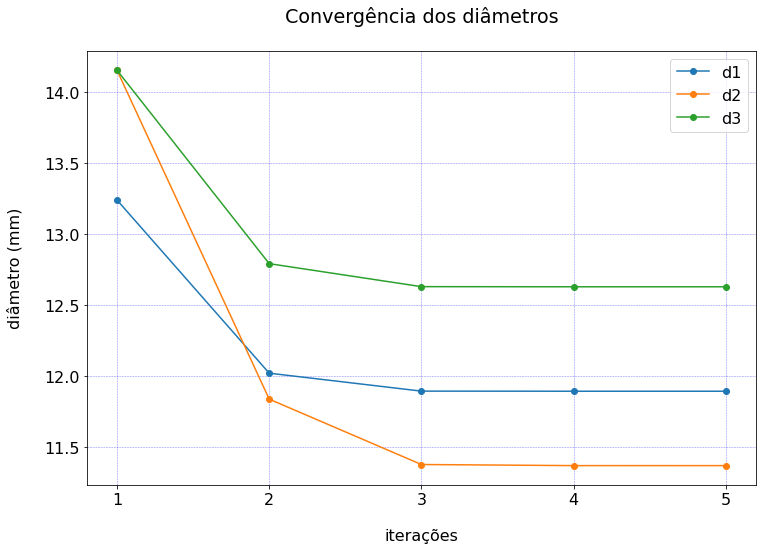

```python
plota_diametros(d1_df,d2_df,d3_df)
```

```python
diametros_df = obtem_diametros_df(d1_df, d2_df, d3_df)
diametros_df
```

|  | diametro | valor [m] |
| --- | --- | --- |
| 0 | 1 | 0.011895 |
| 1 | 2 | 0.011372 |
| 2 | 3 | 0.012629 |

$$ $$

Acima vemos que o maior diâmetro corresponde do $d_{3}$, logo é preciso fazer um ajuste de $25$% para que o $d_{2}$ seja maior que ele. Assim os valores finais dos diâmetros são obtidos. $$ $$

```python
d2 = 1.25 * diametros_df.loc[2,'valor [m]']

diametros_df['ajustado [m]']       = diametros_df['valor [m]']
diametros_df.loc[1,'ajustado [m]'] = d2

round(diametros_df,3).head()
```

|  | diametro | valor [m] | ajustado [m] |
| --- | --- | --- | --- |
| 0 | 1 | 0.012 | 0.012 |
| 1 | 2 | 0.011 | 0.016 |
| 2 | 3 | 0.013 | 0.013 |

$$ $$

## Chavetas

$$ $$

Agora será feito o projeto da chaveta. Será considerado chavetas quadradas com comprimento de $0.5$ $in$ seguido dos passos:

$$ $$

- calcular $F$ e $\tau$ (solicitações) nos pontos $B$ e $C$ (chaveta à esquerda e à direita) $$ $$
- encontrar as tensões médias e máximas $$ $$
- calcular o coeficiente de segurança ($N_{f}$) $$ $$
- caso $N_{fCHAVETA}>=N_{fEIXO}$, redimensionar chaveta $$ $$

$$ $$

```python
# comprimento da chaveta
L_chav = 0.5  *0.0254     # [m]
W_chav = 0.125*0.0254     # [m]
```

```python
# cálculo da resistência a fadiga corrigida

Se_linha = 0.5*Sut_chav # aço vida infinita
C_carreg = 1            # carregamento é flexão alternada

# C_tam
A95 = 0.05*W_chav*W_chav
d_eq = sqrt(A95/0.0766)
print('\nd_eq = %.2f mm\n' % (d_eq*1e3))
C_tam = 1

# material usinado (superfície) (mesmos exe anterior)
A_sup, b_sup  = 4.51, -0.265
C_sup         = A_sup*((Sut_chav*1e-6)**b_sup)

C_temp = 1     # T < 450°C
C_conf = 0.897 # 90%

Se_chav = C_carreg * C_tam * C_sup * C_temp * C_conf * Se_linha
print('Se_chav = %.1f MPa' % (Se_chav*1e-6))
```

```
d_eq = 2.57 mm

Se_chav = 154.6 MPa
```

$$ $$

## Ponto B (diâmetro 1)

$$ $$

```python
# forças na chaveta
Fa = T['alt']/(d1/2)
Fm = T['medio']/(d1/2)

# tensão de cisalhamento
Acis  = L_chav*W_chav      # área
tau_a = Fa/Acis
tau_m = Fm/Acis
```

```python
# tensão de Von Mises
tensao_a = sqrt(3*tau_a**2)
tensao_m = sqrt(3*tau_m**2)

Nf_chav1 = 1/(tensao_a/Se_chav + tensao_m/Sut_chav)

print('\nCoeficiente de segurança de falha por cisalhamento: %.2f\n' % Nf_chav1)
```

```
Coeficiente de segurança de falha por cisalhamento: 3.03
```

```python
# tensão de esmagamento
Aesm = (W_chav/2)*L_chav    # área de esmagamento (metade da largura)
tensao_max = (Fa+Fm)/Aesm   # tensão

Ns_chav1 = Sy_chav/tensao_max

print('\nCoeficiente de segurança por falha de esmagamento: %.2f\n' % Ns_chav1)
```

```
Coeficiente de segurança por falha de esmagamento: 2.55
```

$$ $$

Acima vemos que a chaveta atendeu o necessário para esmagamento, contudo seu coeficiente de segurança para cisalhamento ainda está maior que o do eixo. Assim vamos diminuir com comprimento dela em $10$% para ver se atende o exigido. $$ $$

```python
L_chav1 = L_chav*0.9

# forças na chaveta
Fa = T['alt']/(d1/2)
Fm = T['medio']/(d1/2)

# tensão de cisalhamento
Acis  = (L_chav1)*W_chav      # área
tau_a = Fa/Acis
tau_m = Fm/Acis

# tensão de Von Mises
tensao_a = sqrt(3*tau_a**2)
tensao_m = sqrt(3*tau_m**2)

Nf_chav1 = 1/(tensao_a/Se_chav + tensao_m/Sut_chav)

print('\nCoeficiente de segurança por falha de cisalhamento: %.2f\n' % Nf_chav1)
```

```
Coeficiente de segurança por falha de cisalhamento: 2.73
```

$$ $$

Coeficiente atendido! $$ $$

$$ $$

## Ponto C (diâmetro 3)

$$ $$

```python
# forças na chaveta
Fa = T['alt']/(d3/2)
Fm = T['medio']/(d3/2)

# tensão de cisalhamento
Acis  = L_chav*W_chav      # área
tau_a = Fa/Acis
tau_m = Fm/Acis

# tensão de Von Mises
tensao_a = sqrt(3*tau_a**2)
tensao_m = sqrt(3*tau_m**2)

Nf_chav3 = 1/(tensao_a/Se_chav + tensao_m/Sut_chav)

print('\nCoeficiente de segurança de falha por cisalhamento: %.2f\n' % Nf_chav3)

# tensão de esmagamento
Aesm = (W_chav/2)*L_chav    # área de esmagamento (metade da largura)
tensao_max = (Fa+Fm)/Aesm   # tensão

Ns_chav3 = Sy_chav/tensao_max

print('\nCoeficiente de segurança por falha de esmagamento: %.2f\n' % Ns_chav3)
```

```
Coeficiente de segurança de falha por cisalhamento: 3.22


Coeficiente de segurança por falha de esmagamento: 2.71
```

```python
L_chav2= L_chav*0.8

# forças na chaveta
Fa = T['alt']/(d3/2)
Fm = T['medio']/(d3/2)

# tensão de cisalhamento
Acis  = (L_chav2*W_chav)     # área
tau_a = Fa/Acis
tau_m = Fm/Acis

# tensão de Von Mises
tensao_a = sqrt(3*tau_a**2)
tensao_m = sqrt(3*tau_m**2)

Nf_chav3= 1/(tensao_a/Se_chav + tensao_m/Sut_chav)

print('\nCoeficiente de segurança por falha de cisalhamento: %.2f\n' % Nf_chav3)
```

```
Coeficiente de segurança por falha de cisalhamento: 2.58
```

$$ $$

Os resultados finais são vistos abaixo.

Nota-se que foi necessário redimensionar a chaveta já que seus respectivos coeficientes de segurança de cisalhamento, no primeiro momento, ficaram acima de $3$ ($N_{fEIXO}$). $$ $$

```python
ver = pd.DataFrame({'chaveta'         :[1,3],
                    'Nf'              :[Nf_chav1,Nf_chav3],
                    'Ns'              :[Ns_chav1,Ns_chav3],
                    'comprimento [mm]':[L_chav1,L_chav2],
                    'largura [mm]'    :[W_chav,W_chav]})

ver['comprimento [mm]'] = ver['comprimento [mm]']*1e3
ver['largura [mm]']     = ver['largura [mm]']*1e3
ver = round(ver,1)
ver
```

|  | chaveta | Nf | Ns | comprimento [mm] | largura [mm] |
| --- | --- | --- | --- | --- | --- |
| 0 | 1 | 2.7 | 2.6 | 11.4 | 3.2 |
| 1 | 3 | 2.6 | 2.7 | 10.2 | 3.2 |